# CS 665: DEEP LEARNING - Final Project Code File - Updated as of 04/29/2025

# Deep Learning-Based Pediatric Bone Age Assessment using ResNet-50

## Team Members: Charani Sri Veerla - cveerla@uab.edu

I, *Charani Sri Veerla*, declare that I have completed this computer code in accordance with the UAB Academic Integrity Code and the UAB CS Honor Code. I have read the UAB Academic Integrity Code and understand that any breach of the Code may result in severe penalties.

Student initials: *CSV*

Date: *04/29/2025*

## References

1. **RSNA Pediatric Bone Age Challenge Dataset**  
   Kaggle. RSNA Bone Age Prediction Challenge.  
   https://www.kaggle.com/competitions/rsna-bone-age
2. **PyTorch - Deep Learning Framework**  
   Paszke, A., et al. (2019). PyTorch: An Imperative Style, High-Performance Deep Learning Library.  
   https://pytorch.org/
3. **Torchvision - Models and Transforms**  
   Torchvision Documentation.  
   https://pytorch.org/vision/stable/index.html
4. **ResNet Architecture**  
   He, K., Zhang, X., Ren, S., & Sun, J. (2016). Deep Residual Learning for Image Recognition.  
   https://arxiv.org/abs/1512.03385
5. **TQDM - Progress Bar Library**  
   TQDM Documentation.  
   https://tqdm.github.io/
6. **PIL - Python Imaging Library (via Pillow)**  
   Pillow Documentation.  
   https://pillow.readthedocs.io/en/stable/
7. **Scikit-learn - Machine Learning in Python**  
   Pedregosa, F., et al. (2011). Scikit-learn: Machine Learning in Python.  
   https://scikit-learn.org/stable/
8. **ChatGPT - Code Structuring and Formatting Assistance**  
   OpenAI. ChatGPT by OpenAI for guidance on code organization, formatting, and best practices.  
   https://openai.com/chatgpt

```python
import torch
import torch.nn as nn
import torch.optim as optim
from torchvision import transforms
from torchvision.models import resnet50, ResNet50_Weights
from torch.utils.data import DataLoader, random_split, Dataset
from torch.optim.lr_scheduler import CosineAnnealingLR
import numpy as np
import pandas as pd
import os
from PIL import Image
import matplotlib.pyplot as plt
from sklearn.metrics import mean_absolute_error
from tqdm import tqdm
```

### Entire work is run using GPU. Different versions of code blocks are developed on UAB's Cheaha and this final file is executed on Kaggle using P100 Tesla GPU.

```python
# Device setup
device = torch.device("cuda" if torch.cuda.is_available() else "cpu")
print(f"Using device: {device}")
if device.type == 'cuda':
    print(torch.cuda.get_device_name(0))
```

```
Using device: cuda
Tesla P100-PCIE-16GB
```

### Project's custom Dataset class for image loading and pre-processing

```python
class BoneAgeDataset(Dataset):
    def __init__(self, csv_file, img_dir, transform=None, is_test=False):
        self.data = pd.read_csv(csv_file)
        self.img_dir = img_dir
        self.transform = transform
        self.is_test = is_test
        if not is_test:
            self.labels = self.data['boneage'].values

    def __len__(self):
        return len(self.data)

    def __getitem__(self, idx):
        img_name = str(self.data.iloc[idx]['id']) + '.png'
        img_path = os.path.join(self.img_dir, img_name)
        image = Image.open(img_path).convert('L')

        if self.transform:
            image = self.transform(image)

        if self.is_test:
            return image
        else:
            label = self.labels[idx]
            label = torch.tensor(label, dtype=torch.float32)
            return image, label
```

### Data Augmentation & Transforms

```python
# Data transforms
train_transforms = transforms.Compose([
    transforms.RandomHorizontalFlip(),
    transforms.RandomAffine(degrees=15, translate=(0.1, 0.1), scale=(0.9, 1.1)),
    transforms.ColorJitter(brightness=0.3, contrast=0.3),
    transforms.Resize((224, 224)),
    transforms.ToTensor(),
    transforms.Normalize(mean=[0.485], std=[0.229]),
])

val_transforms = transforms.Compose([
    transforms.Resize((224, 224)),
    transforms.ToTensor(),
    transforms.Normalize(mean=[0.485], std=[0.229]),
])
```

### Dataset folders & file paths

```python
# Dataset paths
train_csv_path = "../input/rsna-bone-age/boneage-training-dataset.csv"
train_images_folder = "../input/rsna-bone-age/boneage-training-dataset/boneage-training-dataset"

test_csv_path = "../input/rsna-bone-age/boneage-test-dataset.csv"
test_images_folder = "../input/rsna-bone-age/boneage-test-dataset/boneage-test-dataset"
```

### Data Preparation & Data Splitting

```python
# Datasets and loaders
full_train_dataset = BoneAgeDataset(train_csv_path, train_images_folder, transform=train_transforms)
train_size = int(0.9 * len(full_train_dataset))
val_size = len(full_train_dataset) - train_size
train_data, val_data = random_split(full_train_dataset, [train_size, val_size])

batch_size = 64
train_loader = DataLoader(train_data, batch_size=batch_size, shuffle=True, num_workers=2)
val_loader = DataLoader(val_data, batch_size=batch_size, shuffle=False, num_workers=2)
```

### Customizing ResNet50 architecture for regression

```python
# Model setup
model = resnet50(weights=ResNet50_Weights.DEFAULT)
model.conv1 = nn.Conv2d(1, 64, kernel_size=7, stride=2, padding=3, bias=False)
model.fc = nn.Linear(model.fc.in_features, 1)
model = model.to(device)
```

### Loss & Optimizers

```python
# Loss and optimizer
criterion = nn.MSELoss()
optimizer = optim.Adam(model.parameters(), lr=0.0005)
scheduler = CosineAnnealingLR(optimizer, T_max=10)
```

### Tolerance based accuracy calculation block

Since it is a regression task, unlike classification, it is very much difficult to predict exact value. So, a buffer or tolerance of 12 months is considered for the model to distinguish between correct and incorrect predictions.

```python
# Tolerance accuracy function
def tolerance_accuracy(preds, labels, tolerance=12):
    return (torch.abs(preds - labels) <= tolerance).float().mean().item() * 100
```

### Training the model with validation monitoring

```python
# Training loop
epochs = 50
train_losses = []
val_losses = []
train_tolerance_acc = []
val_tolerance_acc = []

best_val_acc = 0
patience = 7
patience_counter = 0

for epoch in range(epochs):
    model.train()
    running_loss = 0.0
    running_tol_acc = 0.0

    for images, labels in tqdm(train_loader, desc=f"Training Epoch {epoch+1}"):
        images, labels = images.to(device), labels.to(device)
        optimizer.zero_grad()
        outputs = model(images).squeeze()
        loss = criterion(outputs, labels)
        loss.backward()
        optimizer.step()

        running_loss += loss.item() * images.size(0)
        running_tol_acc += tolerance_accuracy(outputs, labels) * images.size(0)

    scheduler.step()
    epoch_loss = running_loss / len(train_loader.dataset)
    epoch_tol_acc = running_tol_acc / len(train_loader.dataset)
    train_losses.append(epoch_loss)
    train_tolerance_acc.append(epoch_tol_acc)

    model.eval()
    val_loss = 0.0
    val_tol_acc = 0.0

    with torch.no_grad():
        for images, labels in tqdm(val_loader, desc=f"Validation Epoch {epoch+1}"):
            images, labels = images.to(device), labels.to(device)
            outputs = model(images).squeeze()
            loss = criterion(outputs, labels)
            val_loss += loss.item() * images.size(0)
            val_tol_acc += tolerance_accuracy(outputs, labels) * images.size(0)

    val_epoch_loss = val_loss / len(val_loader.dataset)
    val_epoch_tol_acc = val_tol_acc / len(val_loader.dataset)
    val_losses.append(val_epoch_loss)
    val_tolerance_acc.append(val_epoch_tol_acc)

    print(f"Epoch {epoch+1}: Train Loss: {epoch_loss:.4f}, Val Loss: {val_epoch_loss:.4f}")
    print(f"Train Tolerance Accuracy: {epoch_tol_acc:.2f}% | Validation Tolerance Accuracy: {val_epoch_tol_acc:.2f}%")

    if val_epoch_tol_acc > best_val_acc:
        best_val_acc = val_epoch_tol_acc
        patience_counter = 0
        torch.save(model.state_dict(), "best_model.pth")
    else:
        patience_counter += 1
        if patience_counter >= patience:
            print("Early stopping triggered.")
            break
```

```
Epoch 1: Train Loss: 3325.8780, Val Loss: 1096.7896
Train Tolerance Accuracy: 24.72% | Validation Tolerance Accuracy: 25.67%
```

```
Epoch 2: Train Loss: 385.2847, Val Loss: 351.0445
Train Tolerance Accuracy: 46.67% | Validation Tolerance Accuracy: 48.81%
```

```
Epoch 3: Train Loss: 335.1693, Val Loss: 327.1467
Train Tolerance Accuracy: 49.23% | Validation Tolerance Accuracy: 50.00%
```

```
Epoch 4: Train Loss: 297.0128, Val Loss: 381.1323
Train Tolerance Accuracy: 52.11% | Validation Tolerance Accuracy: 46.51%
```

```
Epoch 5: Train Loss: 263.0013, Val Loss: 543.2196
Train Tolerance Accuracy: 55.33% | Validation Tolerance Accuracy: 36.37%
```

```
Epoch 6: Train Loss: 239.4912, Val Loss: 232.4654
Train Tolerance Accuracy: 57.06% | Validation Tolerance Accuracy: 57.29%
```

```
Epoch 7: Train Loss: 226.0889, Val Loss: 323.9531
Train Tolerance Accuracy: 58.10% | Validation Tolerance Accuracy: 49.05%
```

```
Epoch 8: Train Loss: 206.5346, Val Loss: 231.8702
Train Tolerance Accuracy: 60.67% | Validation Tolerance Accuracy: 59.98%
```

```
Epoch 9: Train Loss: 196.3668, Val Loss: 199.3546
Train Tolerance Accuracy: 61.83% | Validation Tolerance Accuracy: 62.68%
```

```
Epoch 10: Train Loss: 187.0114, Val Loss: 199.8074
Train Tolerance Accuracy: 62.62% | Validation Tolerance Accuracy: 62.68%
```

```
Epoch 11: Train Loss: 185.0020, Val Loss: 200.5199
Train Tolerance Accuracy: 63.37% | Validation Tolerance Accuracy: 61.01%
```

```
Epoch 12: Train Loss: 186.8521, Val Loss: 202.7771
Train Tolerance Accuracy: 63.14% | Validation Tolerance Accuracy: 61.25%
```

```
Epoch 13: Train Loss: 192.8420, Val Loss: 221.7030
Train Tolerance Accuracy: 62.28% | Validation Tolerance Accuracy: 58.64%
```

```
Epoch 14: Train Loss: 200.1619, Val Loss: 198.1924
Train Tolerance Accuracy: 61.18% | Validation Tolerance Accuracy: 62.68%
```

```
Epoch 15: Train Loss: 208.9372, Val Loss: 436.6014
Train Tolerance Accuracy: 60.50% | Validation Tolerance Accuracy: 39.62%
```

```
Epoch 16: Train Loss: 221.1607, Val Loss: 278.2302
Train Tolerance Accuracy: 59.28% | Validation Tolerance Accuracy: 53.96%
Early stopping triggered.
```

### Model evaluation

```python
# Load model architecture and best weights
model = resnet50(weights=ResNet50_Weights.DEFAULT)
model.conv1 = nn.Conv2d(1, 64, kernel_size=7, stride=2, padding=3, bias=False)
model.fc = nn.Linear(model.fc.in_features, 1)
model.load_state_dict(torch.load("best_model.pth"))
model = model.to(device)
model.eval()
```

[output not shown]

[output cut: 121 more lines]

[output not shown]

### Testing predictions

```python
from sklearn.metrics import mean_absolute_error, mean_squared_error, r2_score

all_preds = []
all_labels = []

with torch.no_grad():
    for images, labels in val_loader:
        images = images.to(device)
        outputs = model(images).squeeze().cpu().numpy()
        all_preds.extend(outputs)
        all_labels.extend(labels.numpy())

mae = mean_absolute_error(all_labels, all_preds)
rmse = mean_squared_error(all_labels, all_preds, squared=False)
r2 = r2_score(all_labels, all_preds)
tolerance = 12
tolerance_acc = (np.abs(np.array(all_preds) - np.array(all_labels)) <= tolerance).mean() * 100

print(f"MAE: {mae:.2f}")
print(f"RMSE: {rmse:.2f}")
print(f"R^2 Score: {r2:.4f}")
print(f"Tolerance Accuracy (±12 mo): {tolerance_acc:.2f}%")
```

```
MAE: 11.02
RMSE: 14.31
R^2 Score: 0.8827
Tolerance Accuracy (±12 mo): 61.97%
```

### Overall tolerance-based prediction summary of the model

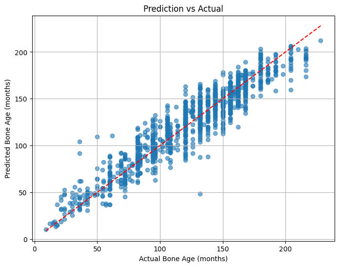

```python
plt.figure(figsize=(8,6))
plt.scatter(all_labels, all_preds, alpha=0.6)
plt.plot([min(all_labels), max(all_labels)], [min(all_labels), max(all_labels)], 'r--')
plt.xlabel("Actual Bone Age (months)")
plt.ylabel("Predicted Bone Age (months)")
plt.title("Prediction vs Actual")
plt.grid()
plt.show()
```

### Sample correct & incorrect predictions based on set tolerance

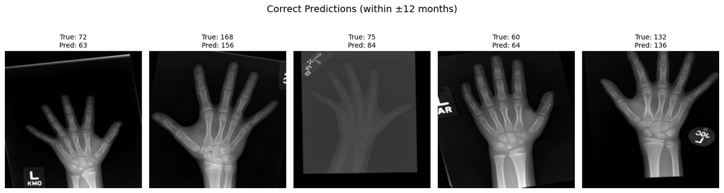

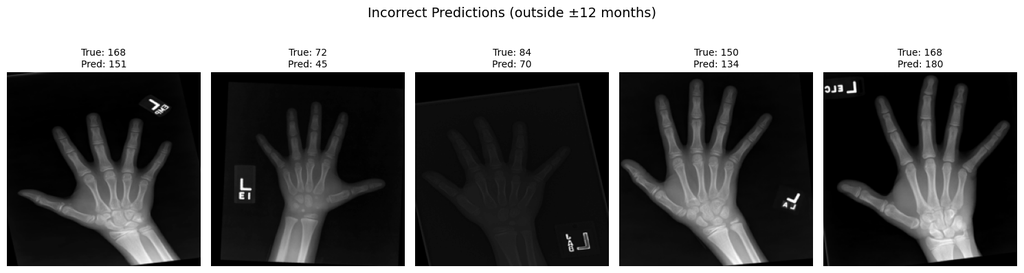

```python
import random

# Pick 5 correct and 5 incorrect samples
correct = [i for i in range(len(all_preds)) if abs(all_preds[i] - all_labels[i]) <= 12]
incorrect = [i for i in range(len(all_preds)) if abs(all_preds[i] - all_labels[i]) > 12]

sample_correct = random.sample(correct, min(5, len(correct)))
sample_incorrect = random.sample(incorrect, min(5, len(incorrect)))

def show_samples(indices, title):
    n = len(indices)
    plt.figure(figsize=(n * 3, 4))
    for i, idx in enumerate(indices):
        image, label = val_data[idx]
        plt.subplot(1, n, i + 1)
        plt.imshow(image.squeeze(), cmap='gray')
        plt.title(f"True: {int(label)}\nPred: {int(all_preds[idx])}", fontsize=10)
        plt.axis('off')
    plt.suptitle(title, fontsize=14, y=1.05)
    plt.tight_layout()
    plt.show()

show_samples(sample_correct, "Correct Predictions (within ±12 months)")
show_samples(sample_incorrect, "Incorrect Predictions (outside ±12 months)")
```

### Tolerance accuracy distribution based on age (in months)

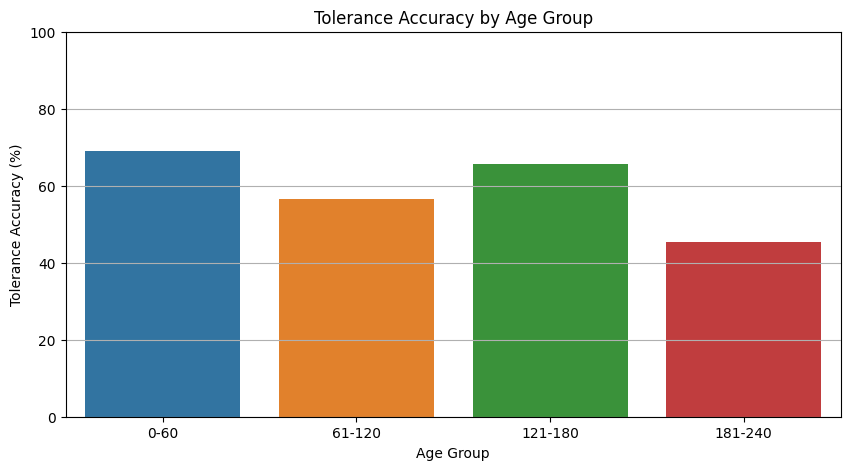

```python
import pandas as pd
import seaborn as sns
import matplotlib.pyplot as plt

# Convert predictions and labels to arrays
preds_array = np.array(all_preds)
labels_array = np.array(all_labels)

# Create dataframe
df = pd.DataFrame({'True': labels_array, 'Predicted': preds_array})
df['Absolute Error'] = np.abs(df['True'] - df['Predicted'])
df['Tolerance OK'] = df['Absolute Error'] <= 12

# Define age bins
bins = [0, 60, 120, 180, 240]
labels_bin = ['0-60', '61-120', '121-180', '181-240']
df['Age Group'] = pd.cut(df['True'], bins=bins, labels=labels_bin)

# Group performance
group_stats = df.groupby('Age Group').agg({
    'Absolute Error': 'mean',
    'Tolerance OK': 'mean'
}).reset_index()
group_stats['Tolerance OK'] = group_stats['Tolerance OK'] * 100

# Plot
plt.figure(figsize=(10, 5))
sns.barplot(x='Age Group', y='Tolerance OK', data=group_stats)
plt.ylim(0, 100)
plt.ylabel("Tolerance Accuracy (%)")
plt.title("Tolerance Accuracy by Age Group")
plt.grid(axis='y')
plt.show()
```

```python
import torch.nn as nn

# Load pre-trained ResNet-50
model = resnet50(weights=ResNet50_Weights.DEFAULT)

# Adjust for grayscale input
model.conv1 = nn.Conv2d(1, 64, kernel_size=7, stride=2, padding=3, bias=False)

# Add Dropout before the final layer
model.fc = nn.Sequential(
    nn.Dropout(p=0.3),
    nn.Linear(model.fc.in_features, 1)
)

model = model.to(device)
```

### Trying with MAE L1 loss & Adam Optimizer!

```python
# Use Mean Absolute Error loss
criterion = nn.L1Loss()

# Optimizer and learning rate scheduler
optimizer = optim.Adam(model.parameters(), lr=0.0005)
scheduler = CosineAnnealingLR(optimizer, T_max=10)
```

```python
# Training loop
epochs = 50
train_losses = []
val_losses = []
train_tolerance_acc = []
val_tolerance_acc = []

best_val_acc = 0
patience = 7
patience_counter = 0

for epoch in range(epochs):
    model.train()
    running_loss = 0.0
    running_tol_acc = 0.0

    for images, labels in tqdm(train_loader, desc=f"Training Epoch {epoch+1}"):
        images, labels = images.to(device), labels.to(device)
        optimizer.zero_grad()
        outputs = model(images).squeeze()
        loss = criterion(outputs, labels)
        loss.backward()
        optimizer.step()

        running_loss += loss.item() * images.size(0)
        running_tol_acc += tolerance_accuracy(outputs, labels) * images.size(0)

    scheduler.step()
    epoch_loss = running_loss / len(train_loader.dataset)
    epoch_tol_acc = running_tol_acc / len(train_loader.dataset)
    train_losses.append(epoch_loss)
    train_tolerance_acc.append(epoch_tol_acc)

    model.eval()
    val_loss = 0.0
    val_tol_acc = 0.0

    with torch.no_grad():
        for images, labels in tqdm(val_loader, desc=f"Validation Epoch {epoch+1}"):
            images, labels = images.to(device), labels.to(device)
            outputs = model(images).squeeze()
            loss = criterion(outputs, labels)
            val_loss += loss.item() * images.size(0)
            val_tol_acc += tolerance_accuracy(outputs, labels) * images.size(0)

    val_epoch_loss = val_loss / len(val_loader.dataset)
    val_epoch_tol_acc = val_tol_acc / len(val_loader.dataset)
    val_losses.append(val_epoch_loss)
    val_tolerance_acc.append(val_epoch_tol_acc)

    print(f"[L1 + Dropout] Epoch {epoch+1}: Train Loss: {epoch_loss:.4f}, Val Loss: {val_epoch_loss:.4f}")
    print(f"Train Tolerance Accuracy: {epoch_tol_acc:.2f}% | Validation Tolerance Accuracy: {val_epoch_tol_acc:.2f}%")

    if val_epoch_tol_acc > best_val_acc:
        best_val_acc = val_epoch_tol_acc
        patience_counter = 0
        torch.save(model.state_dict(), "best_model_l1_dropout.pth")
    else:
        patience_counter += 1
        if patience_counter >= patience:
            print("Early stopping triggered.")
            break
```

```
[L1 + Dropout] Epoch 1: Train Loss: 48.2174, Val Loss: 20.1750
Train Tolerance Accuracy: 19.90% | Validation Tolerance Accuracy: 36.21%
```

```
[L1 + Dropout] Epoch 2: Train Loss: 18.0584, Val Loss: 16.7536
Train Tolerance Accuracy: 41.26% | Validation Tolerance Accuracy: 43.19%
```

```
[L1 + Dropout] Epoch 3: Train Loss: 15.4849, Val Loss: 15.3328
Train Tolerance Accuracy: 46.72% | Validation Tolerance Accuracy: 48.49%
```

```
[L1 + Dropout] Epoch 4: Train Loss: 14.5189, Val Loss: 14.3575
Train Tolerance Accuracy: 49.60% | Validation Tolerance Accuracy: 50.24%
```

```
[L1 + Dropout] Epoch 5: Train Loss: 13.8297, Val Loss: 14.6766
Train Tolerance Accuracy: 52.05% | Validation Tolerance Accuracy: 48.81%
```

```
[L1 + Dropout] Epoch 6: Train Loss: 13.0987, Val Loss: 14.5167
Train Tolerance Accuracy: 54.66% | Validation Tolerance Accuracy: 50.71%
```

```
[L1 + Dropout] Epoch 7: Train Loss: 12.7505, Val Loss: 12.1358
Train Tolerance Accuracy: 55.51% | Validation Tolerance Accuracy: 58.48%
```

```
[L1 + Dropout] Epoch 8: Train Loss: 12.3068, Val Loss: 12.1471
Train Tolerance Accuracy: 56.94% | Validation Tolerance Accuracy: 59.27%
```

```
[L1 + Dropout] Epoch 9: Train Loss: 11.8958, Val Loss: 11.7312
Train Tolerance Accuracy: 58.90% | Validation Tolerance Accuracy: 58.24%
```

```
[L1 + Dropout] Epoch 10: Train Loss: 11.7690, Val Loss: 11.6026
Train Tolerance Accuracy: 59.32% | Validation Tolerance Accuracy: 60.38%
```

```
[L1 + Dropout] Epoch 11: Train Loss: 11.6161, Val Loss: 11.6248
Train Tolerance Accuracy: 60.03% | Validation Tolerance Accuracy: 61.49%
```

```
[L1 + Dropout] Epoch 12: Train Loss: 11.7198, Val Loss: 11.6676
Train Tolerance Accuracy: 59.84% | Validation Tolerance Accuracy: 60.94%
```

```
[L1 + Dropout] Epoch 13: Train Loss: 11.8208, Val Loss: 11.6271
Train Tolerance Accuracy: 58.97% | Validation Tolerance Accuracy: 61.17%
```

```
[L1 + Dropout] Epoch 14: Train Loss: 11.8646, Val Loss: 11.9072
Train Tolerance Accuracy: 58.67% | Validation Tolerance Accuracy: 59.75%
```

```
[L1 + Dropout] Epoch 15: Train Loss: 12.1405, Val Loss: 12.6223
Train Tolerance Accuracy: 58.67% | Validation Tolerance Accuracy: 56.10%
```

```
[L1 + Dropout] Epoch 16: Train Loss: 12.4868, Val Loss: 14.3647
Train Tolerance Accuracy: 57.08% | Validation Tolerance Accuracy: 50.55%
```

```
[L1 + Dropout] Epoch 17: Train Loss: 12.4797, Val Loss: 13.4288
Train Tolerance Accuracy: 56.97% | Validation Tolerance Accuracy: 52.61%
```

```
[L1 + Dropout] Epoch 18: Train Loss: 12.5712, Val Loss: 17.4042
Train Tolerance Accuracy: 55.99% | Validation Tolerance Accuracy: 38.27%
Early stopping triggered.
```

```python
def evaluate_model(model_path, name):
    model = resnet50(weights=ResNet50_Weights.DEFAULT)
    model.conv1 = nn.Conv2d(1, 64, kernel_size=7, stride=2, padding=3, bias=False)
    model.fc = nn.Sequential(
        nn.Dropout(p=0.3),  # adjust if model had different dropout
        nn.Linear(model.fc.in_features, 1)
    )
    model.load_state_dict(torch.load(model_path))
    model = model.to(device)
    model.eval()

    preds, labels = [], []
    with torch.no_grad():
        for images, targets in val_loader:
            images = images.to(device)
            outputs = model(images).squeeze().cpu().numpy()
            preds.extend(outputs)
            labels.extend(targets.numpy())

    mae = mean_absolute_error(labels, preds)
    rmse = mean_squared_error(labels, preds, squared=False)
    r2 = r2_score(labels, preds)
    tol_acc = (np.abs(np.array(preds) - np.array(labels)) <= 12).mean() * 100

    print(f"{name} - MAE: {mae:.2f} | RMSE: {rmse:.2f} | R2: {r2:.4f} | Tolerance Acc: {tol_acc:.2f}%")
    return None
```

```python
evaluate_model("best_model_l1_dropout.pth", "L1 + Dropout Model")
```

```
L1 + Dropout Model - MAE: 11.51 | RMSE: 15.15 | R2: 0.8685 | Tolerance Acc: 61.97%
```